# Canine Skin Microbiome: ITS Change-Point Analysis

### PCoA Axis 2: Control vs. Surgical

Axis 2 explains about 6.13% of the variation

Model = lmer(pc2 ~ Day_Order*Sample_Site + (1 | Dog_ID))* Contrasts between estimated marginal means of timepoints from model, using Tukey-adjusting p-values

**Results:**

Surgical Samples: There are no significant differences between PCoA Axis 2 coordinates amongst timepoints

Control Samples: There are no significant differences between PCoA Axis 2 coordinates amongst timepoints

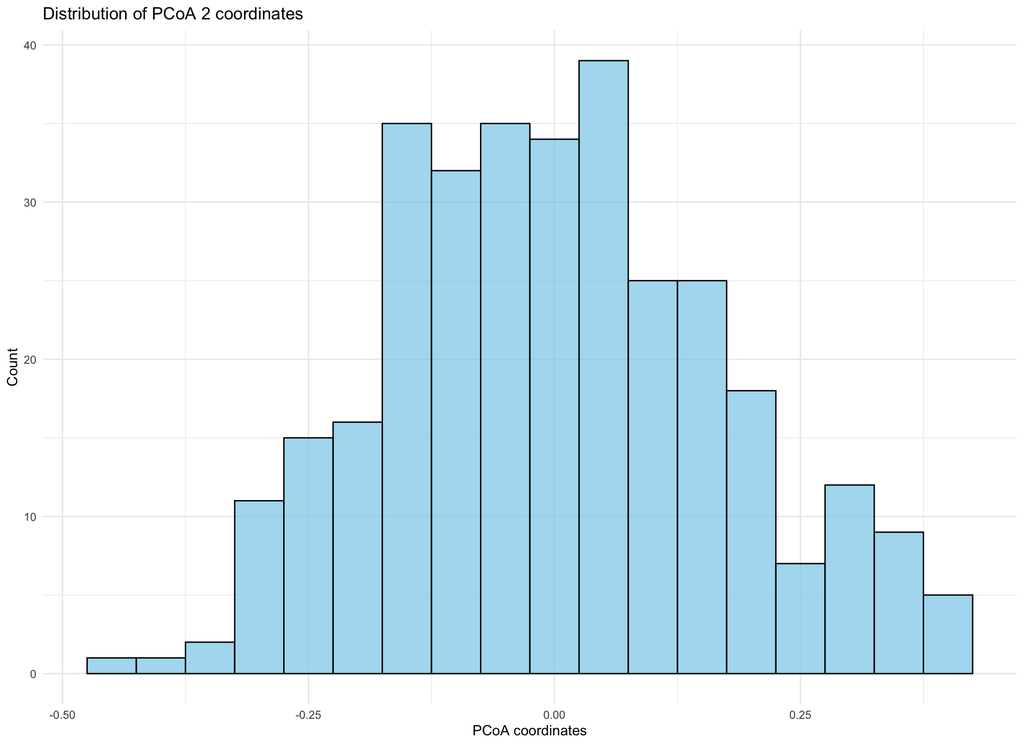

```r
coord <- as.vector(paired_sample_data_2$pc2)
# Plot Distribution of PCoA coordinates
histogram_distances <- ggplot(data = data.frame(coord), aes(x = coord)) +
  geom_histogram(binwidth = 0.05, fill = "skyblue", color = "black", alpha = 0.7) +
  theme_minimal() +
  labs(
    title = "Distribution of PCoA 2 coordinates",
    x = "PCoA coordinates",
    y = "Count"
  )

print(histogram_distances)
```

```r
lmer_pcoa_2 <- lmer(data = paired_sample_data_2, pc2 ~ Day_Order*Sample_Site + (1 | Dog_ID))

anova(lmer_pcoa_2)
```

|  | npar | Sum Sq | Mean Sq | F value |
| --- | --- | --- | --- | --- |
| Day_Order | 10 | 2.642515e-01 | 2.642515e-02 | 1.533695354 |
| Sample_Site | 1 | 9.842622e-05 | 9.842622e-05 | 0.005712582 |
| Day_Order:Sample_Site | 10 | 5.378697e-02 | 5.378697e-03 | 0.312175438 |

```r
summary(lmer_pcoa_2)
```

```
## Linear mixed model fit by REML ['lmerMod']
## Formula: pc2 ~ Day_Order * Sample_Site + (1 | Dog_ID)
##    Data: paired_sample_data_2
##
## REML criterion at convergence: -262.1
##
## Scaled residuals:
##     Min      1Q  Median      3Q     Max
## -3.1445 -0.5519 -0.0517  0.5197  3.3886
##
## Random effects:
##  Groups   Name        Variance Std.Dev.
##  Dog_ID   (Intercept) 0.01284  0.1133
##  Residual             0.01723  0.1313
## Number of obs: 322, groups:  Dog_ID, 19
##
## Fixed effects:
##                                                      Estimate Std. Error
## (Intercept)                                        -0.0189694  0.0428970
## Day_OrderDay 0a - Pre Surgery                       0.0119842  0.0481971
## Day_OrderDay 0c - Post Surgery                      0.0104890  0.0512877
## Day_OrderDay 1                                     -0.0334970  0.0503002
## Day_OrderDay 3                                      0.0413982  0.0461795
## Day_OrderWeek 1                                     0.0309722  0.0491135
## Day_OrderWeek 2                                     0.0555894  0.0474197
## Day_OrderWeek 3                                     0.0337180  0.0468383
## Day_OrderWeek 4                                    -0.0004009  0.0476004
## Day_OrderWeek 5                                     0.0937132  0.0474952
## Day_OrderWeek 6                                     0.0807101  0.0559737
## Sample_SiteSurgical                                 0.0436321  0.0479301
## Day_OrderDay 0a - Pre Surgery:Sample_SiteSurgical  -0.0480474  0.0677834
## Day_OrderDay 0c - Post Surgery:Sample_SiteSurgical -0.0359517  0.0718952
## Day_OrderDay 1:Sample_SiteSurgical                 -0.0124374  0.0703422
## Day_OrderDay 3:Sample_SiteSurgical                 -0.0772608  0.0648977
## Day_OrderWeek 1:Sample_SiteSurgical                -0.0425115  0.0689832
## Day_OrderWeek 2:Sample_SiteSurgical                -0.0854818  0.0667159
## Day_OrderWeek 3:Sample_SiteSurgical                -0.0557162  0.0657596
## Day_OrderWeek 4:Sample_SiteSurgical                -0.0151924  0.0667159
## Day_OrderWeek 5:Sample_SiteSurgical                -0.0450361  0.0667159
## Day_OrderWeek 6:Sample_SiteSurgical                -0.0298369  0.0782696
```

[output cut: 8 more lines]

```
## Day_OrderWeek 3                                      0.720
## Day_OrderWeek 4                                     -0.008
## Day_OrderWeek 5                                      1.973
## Day_OrderWeek 6                                      1.442
## Sample_SiteSurgical                                  0.910
## Day_OrderDay 0a - Pre Surgery:Sample_SiteSurgical   -0.709
## Day_OrderDay 0c - Post Surgery:Sample_SiteSurgical  -0.500
## Day_OrderDay 1:Sample_SiteSurgical                  -0.177
## Day_OrderDay 3:Sample_SiteSurgical                  -1.191
## Day_OrderWeek 1:Sample_SiteSurgical                 -0.616
## Day_OrderWeek 2:Sample_SiteSurgical                 -1.281
## Day_OrderWeek 3:Sample_SiteSurgical                 -0.847
## Day_OrderWeek 4:Sample_SiteSurgical                 -0.228
## Day_OrderWeek 5:Sample_SiteSurgical                 -0.675
## Day_OrderWeek 6:Sample_SiteSurgical                 -0.381
```